# Homework 5

STAT 334

Krishnanshu Gupta, Ishaan Sathaye, Sreshta Talluri

2024-06-02

# Question 1

```r
dwaine <- read_xls("./DwaineStudios.xls")
head(dwaine)
```

```
## # A tibble: 6 × 3
##   youth income sales
##   <dbl>  <dbl> <dbl>
## 1  68.5   16.7  174.
## 2  45.2   16.8  164.
## 3  91.3   18.2  244.
## 4  47.8   16.3  155.
## 5  46.9   17.3  182.
## 6  66.1   18.2  208.
```

## Part (a)

```r
model <- lm(sales ~ youth + income, data = dwaine)
summary(model)
```

```
##
## Call:
## lm(formula = sales ~ youth + income, data = dwaine)
##
## Residuals:
##      Min       1Q   Median       3Q      Max
## -18.4239  -6.2161   0.7449   9.4356  20.2151
##
## Coefficients:
##             Estimate Std. Error t value Pr(>|t|)
## (Intercept) -68.8571    60.0170  -1.147   0.2663
## youth         1.4546     0.2118   6.868    2e-06 ***
## income        9.3655     4.0640   2.305   0.0333 *
## ---
## Signif. codes:  0 '***' 0.001 '**' 0.01 '*' 0.05 '.' 0.1 ' ' 1
##
## Residual standard error: 11.01 on 18 degrees of freedom
## Multiple R-squared:  0.9167, Adjusted R-squared:  0.9075
## F-statistic:  99.1 on 2 and 18 DF,  p-value: 1.921e-10
```

For every one unit increase in the number of people aged 16 or younger in the community (in thousands; every 1000 people increase), there is an associated increase of $1454.6 in predicted sales (for their portraits), holding the per capital disposable personal income constant.

91.67% of the variability in sales in a community is explained by the regression model with predictors for the number of people aged 16 or younger and the per capital disposable personal income.

## Part (b)

The slopes represent the changes in sales per unit change of the respective predictors. Since youth is measured in thousands of people and income is measured in thousands of dollars, the slopes are not directly comparable because they have different units. To compare, we can standardize the variables.

## Part (c)

```r
# Perform the regression with standardized variables
std_model <- lm(scale(sales) ~ scale(youth) + scale(income), data = dwaine)
summary(std_model)
```

```
##
## Call:
## lm(formula = scale(sales) ~ scale(youth) + scale(income), data = dwaine)
##
## Residuals:
##      Min       1Q   Median       3Q      Max
## -0.50907 -0.17176  0.02058  0.26071  0.55856
##
## Coefficients:
##                Estimate Std. Error t value Pr(>|t|)
## (Intercept)   6.142e-16  6.637e-02   0.000   1.0000
## scale(youth)  7.484e-01  1.090e-01   6.868    2e-06 ***
## scale(income) 2.511e-01  1.090e-01   2.305   0.0333 *
## ---
## Signif. codes:  0 '***' 0.001 '**' 0.01 '*' 0.05 '.' 0.1 ' ' 1
##
## Residual standard error: 0.3041 on 18 degrees of freedom
## Multiple R-squared:  0.9167, Adjusted R-squared:  0.9075
## F-statistic:  99.1 on 2 and 18 DF,  p-value: 1.921e-10
```

In this model, the intercept is zero because standardized variables have a mean of zero (so, checks out). Therefore, when all predictors are at their mean value, the predicted response value is also at its mean, which is all zero.

The r-squared of the standardized model is the same as the r-squared value from the original model. This is because standardization does not change the fit of the model, it only changes the scale of the coefficients.

## Part (d)

For every one standard deviation increase in the number of people aged 16 or younger in the community (in thousands; every 1000 people increase), there is an associated increase of 0.7484 standard deviations in predicted sales (for their portraits), holding the per capital disposable personal income constant.

## Part (e)

Since we have standardized the variables, we can directly compare the slopes as they are unit-less. The slope for std_youth is 0.7484 and the slope for std_income is 0.2511. The slope for std_youth is greater than the slope for std_income, therefore the number of people aged 16 or younger in the community has a larger impact on expected sales.

# Question 2

```r
derby <- read_xls("./KYDerby12.xls")
str(derby)
```

```
## tibble [138 × 4] (S3: tbl_df/tbl/data.frame)
##  $ Year     : num [1:138] 1875 1876 1877 1878 1879 ...
##  $ winner   : chr [1:138] "Aristides" "Vagrant" "Baden-Baden" "Day Star" ...
##  $ Time     : num [1:138] 158 158 158 157 157 ...
##  $ condition: chr [1:138] "fast" "fast" "fast" "good" ...
```

```r
derby$condition=factor(derby$condition)
```

## Part (a)

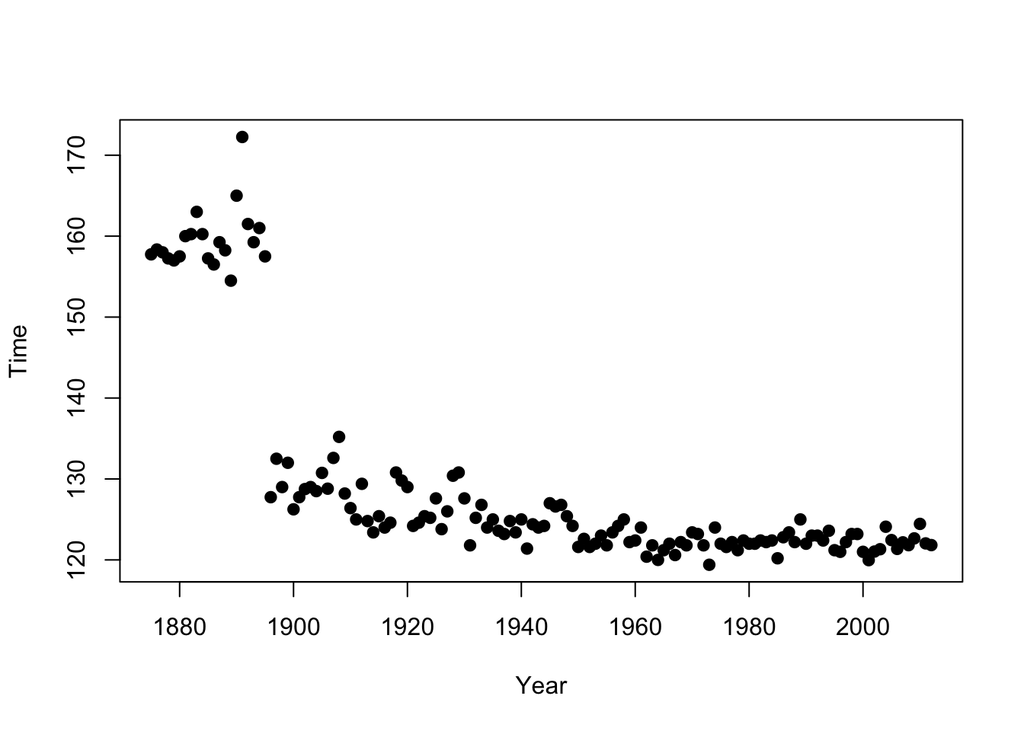

```r
plot(Time~Year,data=derby,pch=19)
```

```r
# Set distance to 1.5 for Year<1896 and 1.25 else
derby$Distance = ifelse(derby$Year<1896, 1.5, 1.25)

# Create speed variable by dividing distance over time
# multiply by 5280 to change units to ft/sec (instead of mi/sec)
derby$Speed = derby$Distance / derby$Time * 5280

#view structure of updated data frame
str(derby)
```

```
## tibble [138 × 6] (S3: tbl_df/tbl/data.frame)
##  $ Year     : num [1:138] 1875 1876 1877 1878 1879 ...
##  $ winner   : chr [1:138] "Aristides" "Vagrant" "Baden-Baden" "Day Star" ...
##  $ Time     : num [1:138] 158 158 158 157 157 ...
##  $ condition: Factor w/ 3 levels "fast","good",..: 1 1 1 2 1 2 1 2 3 2 ...
##  $ Distance : num [1:138] 1.5 1.5 1.5 1.5 1.5 1.5 1.5 1.5 1.5 1.5 ...
##  $ Speed    : num [1:138] 50.2 50 50.1 50.4 50.4 ...
```

## Part (b)

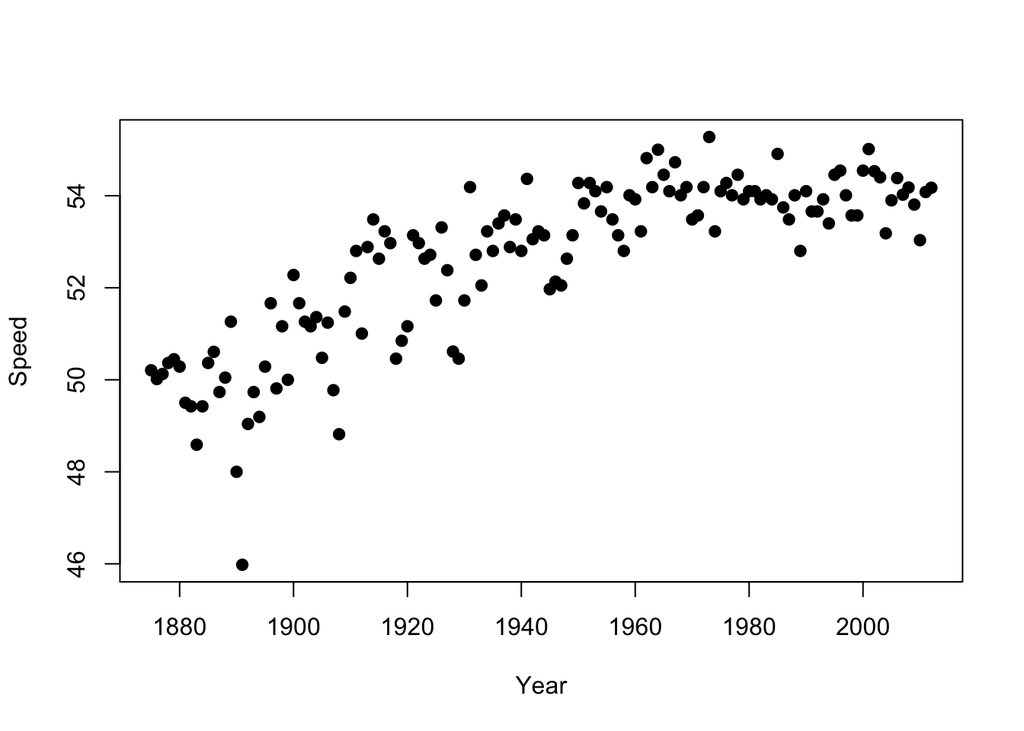

```r
plot(Speed~Year,data=derby,pch=19)
```

## Part (c)

```r
fit.derby=lm(Speed~Year+I(Year^2),data=derby)
summary(fit.derby)
```

```
##
## Call:
## lm(formula = Speed ~ Year + I(Year^2), data = derby)
##
## Residuals:
##     Min      1Q  Median      3Q     Max
## -4.2803 -0.4563  0.0402  0.5988  1.7038
##
## Coefficients:
##               Estimate Std. Error t value Pr(>|t|)
## (Intercept) -1.379e+03  2.031e+02  -6.790 3.24e-10 ***
## Year         1.437e+00  2.091e-01   6.875 2.09e-10 ***
## I(Year^2)   -3.604e-04  5.378e-05  -6.701 5.15e-10 ***
## ---
## Signif. codes:  0 '***' 0.001 '**' 0.01 '*' 0.05 '.' 0.1 ' ' 1
##
## Residual standard error: 0.8967 on 135 degrees of freedom
## Multiple R-squared:  0.7519, Adjusted R-squared:  0.7483
## F-statistic: 204.6 on 2 and 135 DF,  p-value: < 2.2e-16
```

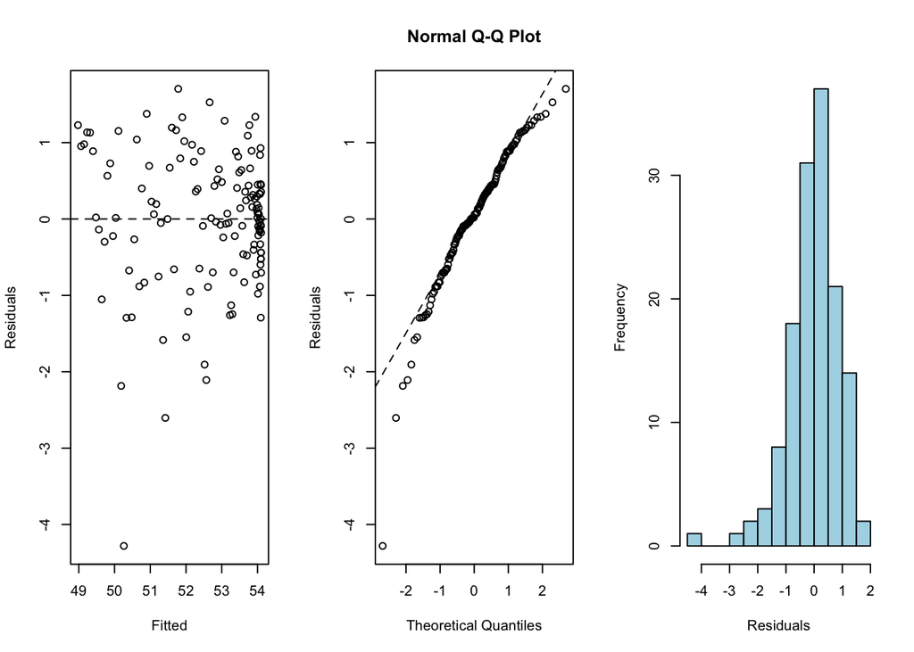

```r
par(mfrow=c(1,3))
plot(resid(fit.derby)~fitted(fit.derby), xlab='Fitted', ylab='Residuals');abline(h=0,lty=2)
qqnorm(resid(fit.derby),ylab='Residuals'); qqline(resid(fit.derby),lty=2)
hist(resid(fit.derby),main="", xlab="Residuals",col='lightblue')
```

```r
vif(fit.derby)
```

```
##      Year I(Year^2)
##  11903.92  11903.92
```

The $R^2$ value is 0.7519 and the $s$ value is 0.8967. The overall regression model is significant because the p-value is low and the F-statistic is large, given by the model utility test. The quadratic term as well as the linear term is significant given the low p-values. The VIF values for the linear and quadratic term are very high with values of 11903.92, which means there is evidence of multi-collinearity (since same variable is just being transformed). From the residual plots there does not seem to be any major violations of equal variance and linearity. Other than the unusual observation, normality also seems to be fine.

## Part (d)

```r
derby$YearC=derby$Year-mean(derby$Year)
fit.derbyC=lm(Speed~YearC+I(YearC^2),data=derby)
summary(fit.derbyC)
```

```
##
## Call:
## lm(formula = Speed ~ YearC + I(YearC^2), data = derby)
##
## Residuals:
##     Min      1Q  Median      3Q     Max
## -4.2803 -0.4563  0.0402  0.5988  1.7038
##
## Coefficients:
##               Estimate Std. Error t value Pr(>|t|)
## (Intercept)  5.317e+01  1.145e-01 464.383  < 2e-16 ***
## YearC        3.657e-02  1.916e-03  19.088  < 2e-16 ***
## I(YearC^2)  -3.604e-04  5.378e-05  -6.701 5.15e-10 ***
## ---
## Signif. codes:  0 '***' 0.001 '**' 0.01 '*' 0.05 '.' 0.1 ' ' 1
##
## Residual standard error: 0.8967 on 135 degrees of freedom
## Multiple R-squared:  0.7519, Adjusted R-squared:  0.7483
## F-statistic: 204.6 on 2 and 135 DF,  p-value: < 2.2e-16
```

```r
vif(fit.derbyC)
```

```
##      YearC I(YearC^2)
##          1          1
```

The VIF value is now 1 for both, which means the multi-collinearity has improved.

## Part (e)

```r
mean(derby$Year)
```

```
## [1] 1943.5
```

In the mean year of 1943.5, we expect the speed to be 53.17 feet per second.

## Part (f)

The sign of the first regression coefficient which is the linear term is positive, which means that initially as the year increases the speed also increases. The sign of the second regression coefficient which is the quadratic term is negative, which means that the rate of increase in speed slows down over time and eventually starts to decline for very large values of the year. This behavior does make sense in context because early on there could be significant improvements in technology would mean a noticeable increase in speed. After that improvements may reach their limits which means the increase in speed slows down, which could be the flattening in the scatter plot. For larger years, the speeds might not increase and could even slightly decrease due to natural limits.

## Part (g)

```r
x0=data.frame(YearC=(2013-mean(derby$Year)))
predict(fit.derbyC, x0, interval = "prediction", level = 0.95)
```

```
##        fit      lwr      upr
## 1 53.97465 52.14269 55.80662
```

We are 95% confident that in the year 2013 a horse would have speed that falls in between 52.14 ft/sec and 55.81 ft/sec.

## Part (h)

```r
6601.049868766404199/(120+12+0.089)
```

```
## [1] 49.97426
```

Source: [HorseLoversMath](https://www.horseloversmath.com/orb-wins-the-kentucky-derby/#:~:text=Orb%20won%20the%202013%20Kentucky,8%20feet%20or%202.4%20metres.)

## Part (i)

```r
fit.derby3=lm(Speed~YearC+I(YearC^2)+I(YearC^3),data=derby)
summary(fit.derby3)
```

```
##
## Call:
## lm(formula = Speed ~ YearC + I(YearC^2) + I(YearC^3), data = derby)
##
## Residuals:
##     Min      1Q  Median      3Q     Max
## -4.2662 -0.5078  0.0497  0.5405  1.8606
##
## Coefficients:
##               Estimate Std. Error t value Pr(>|t|)
## (Intercept)  5.317e+01  1.136e-01 467.944  < 2e-16 ***
## YearC        4.422e-02  4.755e-03   9.300 3.50e-16 ***
## I(YearC^2)  -3.604e-04  5.337e-05  -6.752 4.03e-10 ***
## I(YearC^3)  -2.677e-06  1.526e-06  -1.754   0.0816 .
## ---
## Signif. codes:  0 '***' 0.001 '**' 0.01 '*' 0.05 '.' 0.1 ' ' 1
##
## Residual standard error: 0.8899 on 134 degrees of freedom
## Multiple R-squared:  0.7575, Adjusted R-squared:  0.7521
## F-statistic: 139.5 on 3 and 134 DF,  p-value: < 2.2e-16
```

```r
Anova(fit.derby3, type = 'II')
```

```
## Anova Table (Type II tests)
##
## Response: Speed
##             Sum Sq  Df F value    Pr(>F)
## YearC       68.493   1 86.4942 3.503e-16 ***
## I(YearC^2)  36.101   1 45.5886 4.034e-10 ***
## I(YearC^3)   2.438   1  3.0782   0.08163 .
## Residuals  106.112 134
## ---
## Signif. codes:  0 '***' 0.001 '**' 0.01 '*' 0.05 '.' 0.1 ' ' 1
```

Using a Single Coefficient Test, we can test the null whether the cubic term beta is 0 and the alt hypothesis where it is not 0. With a F stat of $t^2 = 3.07$, the F statistic is pretty low and the p-value is relatively large. We do not have sufficient evidence to believe that the cubic variable is any different from 0 after adjusting for the linear and quadratic terms. This means that the variable does not significantly improve the model containing the other terms and it is not useful to the model.

# Question 3

## Part (a)

```r
possumData=read.csv("possum.csv", header = TRUE, sep = ",")
str(possumData)
```

```
## 'data.frame':    104 obs. of  7 variables:
##  $ pop    : chr  "vic" "vic" "vic" "vic" ...
##  $ sex    : chr  "m" "f" "f" "f" ...
##  $ age    : int  8 6 6 6 2 1 2 6 9 6 ...
##  $ head_l : num  94.1 92.5 94 93.2 91.5 93.1 95.3 94.8 93.4 91.8 ...
##  $ skull_w: num  60.4 57.6 60 57.1 56.3 54.8 58.2 57.6 56.3 58 ...
##  $ total_l: num  89 91.5 95.5 92 85.5 90.5 89.5 91 91.5 89.5 ...
##  $ tail_l : num  36 36.5 39 38 36 35.5 36 37 37 37.5 ...
```

```r
possumData$pop=factor(possumData$pop)
possumData$sex=factor(possumData$sex)
str(possumData)
```

```
## 'data.frame':    104 obs. of  7 variables:
##  $ pop    : Factor w/ 2 levels "other","vic": 2 2 2 2 2 2 2 2 2 2 ...
##  $ sex    : Factor w/ 2 levels "f","m": 2 1 1 1 1 1 2 1 1 1 ...
##  $ age    : int  8 6 6 6 2 1 2 6 9 6 ...
##  $ head_l : num  94.1 92.5 94 93.2 91.5 93.1 95.3 94.8 93.4 91.8 ...
##  $ skull_w: num  60.4 57.6 60 57.1 56.3 54.8 58.2 57.6 56.3 58 ...
##  $ total_l: num  89 91.5 95.5 92 85.5 90.5 89.5 91 91.5 89.5 ...
##  $ tail_l : num  36 36.5 39 38 36 35.5 36 37 37 37.5 ...
```

## Part (b)

```r
which(is.na(possumData), arr.ind=TRUE)
```

```
##      row col
## [1,]  44   3
## [2,]  46   3
```

```r
possumData[c(44,46),]
```

```
##    pop sex age head_l skull_w total_l tail_l
## 44 vic   m  NA   85.1    51.5      76   35.5
## 46 vic   m  NA   91.4    54.4      84   35.0
```

Rows 44 and 46 have missing values for the age variable.

## Part (c)

```r
lmodAge = lm(age~., data=possumData)
possumData[c(44,46),'age']=predict(lmodAge,possumData[c(44,46),])
possumData[c(44,46),]
```

```
##    pop sex      age head_l skull_w total_l tail_l
## 44 vic   m 2.672532   85.1    51.5      76   35.5
## 46 vic   m 3.459138   91.4    54.4      84   35.0
```

The imputed values for age are approximately 2.673 and 3.459.

## Part (d)

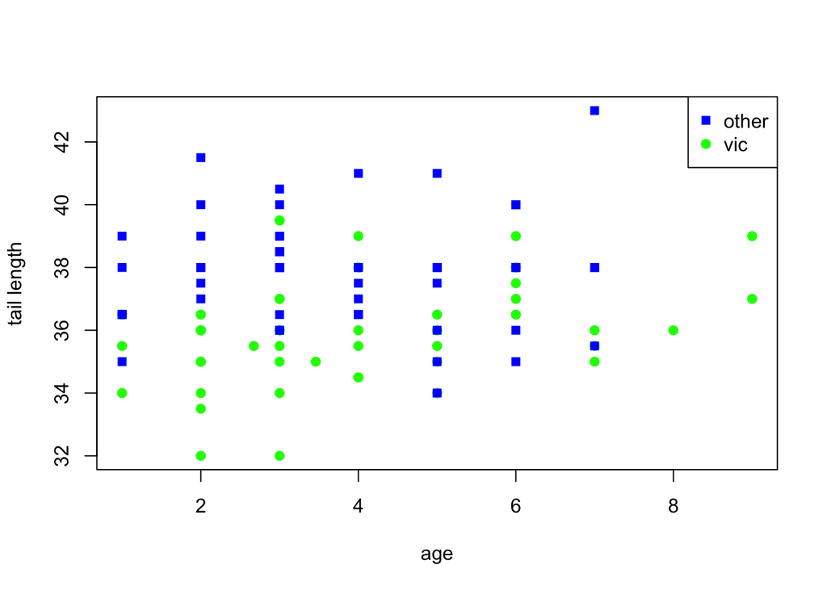

```r
plot(tail_l ~ age, data=possumData,
     xlab='age', ylab= 'tail length',
     col=c('blue','green')[pop],
     pch=c(15, 19)[pop])

legend('topright',
       legend=levels(possumData$pop),
       col=c('blue','green'),
       pch=c(15, 19))
```

## Part (e)

```r
modAP = lm(tail_l ~ age + pop, data = possumData)
summary(modAP)
```

```
##
## Call:
## lm(formula = tail_l ~ age + pop, data = possumData)
##
## Residuals:
##     Min      1Q  Median      3Q     Max
## -4.0820 -0.9116 -0.0802  0.7537  4.5824
##
## Coefficients:
##             Estimate Std. Error t value Pr(>|t|)
## (Intercept) 37.24288    0.39472  94.353  < 2e-16 ***
## age          0.16782    0.08837   1.899   0.0604 .
## popvic      -1.97620    0.33546  -5.891 5.08e-08 ***
## ---
## Signif. codes:  0 '***' 0.001 '**' 0.01 '*' 0.05 '.' 0.1 ' ' 1
##
## Residual standard error: 1.694 on 101 degrees of freedom
## Multiple R-squared:  0.2671, Adjusted R-squared:  0.2526
## F-statistic:  18.4 on 2 and 101 DF,  p-value: 1.53e-07
```

```r
levels(possumData$pop)
```

```
## [1] "other" "vic"
```

The reference level for pop is other in this model.

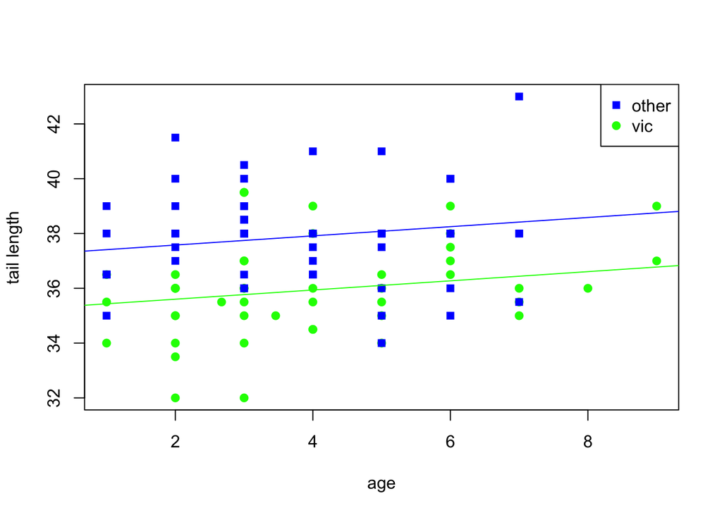

```r
plot(tail_l ~ age, data=possumData,
     xlab='age', ylab= 'tail length',
     col=c('blue','green')[pop],
     pch=c(15, 19)[pop])

legend('topright',
       legend=levels(possumData$pop),
       col=c('blue','green'),
       pch=c(15, 19))

#Fitted line for other
abline(37.24288, 0.16782, col='blue')

#Fitted line for vic
abline(37.24288 - 1.97620, 0.16782, col='green')
```

## Part (f)

```r
x0 = data.frame(age = 4, pop = 'vic')
predict(modAP, x0)
```

```
##        1
## 35.93795
```

```r
x1 = data.frame(age = 2, pop = 'other')
predict(modAP, x1)
```

```
##        1
## 37.57851
```

The predicted tail length of a 2-year-old brushtail possum from NSW/Queensland is 37.579cm.

## Question 4

```r
preemp <- read_xls("./preemp.xls")
head(preemp)
```

```
## # A tibble: 6 × 3
##   pretest.score job.performance race
##           <dbl>           <dbl> <chr>
## 1          0.28            1.83 minority
## 2          0.97            4.59 minority
## 3          1.25            2.97 minority
## 4          2.46            8.14 minority
## 5          2.51            8    minority
## 6          1.17            3.3  minority
```

## Part (a)

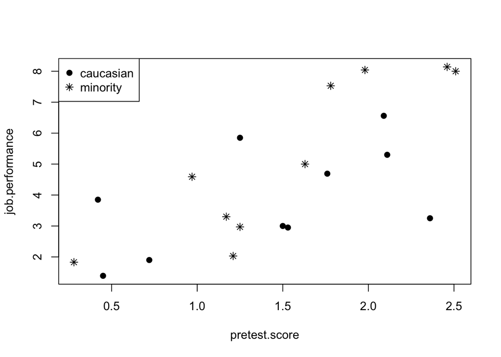

```r
# convert race to a factor
preemp$race <- as.factor(preemp$race)

# Create the scatterplot
plot(job.performance ~ pretest.score, data = preemp, pch = c(19, 8)[preemp$race])
legend('topleft', legend = levels(preemp$race), pch = c(19, 8))
```

For both groups, it appears as though there is a positive linear relationship between job employment and test scores. The behavior for both groups looks roughly similar, however, the slope for the minority group seems to be steeper/greater than the slope for the caucasian group.

## Part (b)

```r
# Fit the parallel lines regression model
parallel_model <- lm(job.performance ~ pretest.score + race, data = preemp)
summary(parallel_model)
```

```
##
## Call:
## lm(formula = job.performance ~ pretest.score + race, data = preemp)
##
## Residuals:
##     Min      1Q  Median      3Q     Max
## -2.7872 -1.0370 -0.2095  0.9198  2.3645
##
## Coefficients:
##               Estimate Std. Error t value Pr(>|t|)
## (Intercept)     0.6120     0.8870   0.690 0.499578
## pretest.score   2.2988     0.5225   4.400 0.000391 ***
## raceminority    1.0276     0.6909   1.487 0.155246
## ---
## Signif. codes:  0 '***' 0.001 '**' 0.01 '*' 0.05 '.' 0.1 ' ' 1
##
## Residual standard error: 1.54 on 17 degrees of freedom
## Multiple R-squared:  0.5724, Adjusted R-squared:  0.5221
## F-statistic: 11.38 on 2 and 17 DF,  p-value: 0.0007312
```

**Null Hypothesis:** $\beta_2$ = 0 ($\beta_2$ being the coefficient for raceminority)

**Alternate Hypothesis:** $\beta_2$ $\neq$ 0 ($\beta_2$ being the coefficient for raceminority)

df = n - k - 1 = 20 - 2 - 1 = 17

t-value = 1.487

p-value = 0.155246

Since the p-value is greater than 0.05, we have insufficient evidence to reject the null hypothesis. Therefore, we do not have strong evidence to believe that mean performance score for minorities differs from the mean performance score for caucasians (after adjusting for the pretest scores).

## Part (c)

```r
# Fit the separate lines regression model
separate_model <- lm(job.performance ~ pretest.score * race, data = preemp)
summary(separate_model)
```

```
##
## Call:
## lm(formula = job.performance ~ pretest.score * race, data = preemp)
##
## Residuals:
##     Min      1Q  Median      3Q     Max
## -2.0734 -1.0594 -0.2548  1.2830  2.1980
##
## Coefficients:
##                            Estimate Std. Error t value Pr(>|t|)
## (Intercept)                  2.0103     1.0501   1.914   0.0736 .
## pretest.score                1.3134     0.6704   1.959   0.0677 .
## raceminority                -1.9132     1.5403  -1.242   0.2321
## pretest.score:raceminority   1.9975     0.9544   2.093   0.0527 .
## ---
## Signif. codes:  0 '***' 0.001 '**' 0.01 '*' 0.05 '.' 0.1 ' ' 1
##
## Residual standard error: 1.407 on 16 degrees of freedom
## Multiple R-squared:  0.6643, Adjusted R-squared:  0.6013
## F-statistic: 10.55 on 3 and 16 DF,  p-value: 0.0004511
```

**Null Hypothesis:** $\beta_3$ = 0 ($\beta_3$ being the coefficient for pretest.score:raceminority)

**Alternate Hypothesis:** $\beta_3$ $\neq$ 0 ($\beta_3$ being the coefficient for pretest.score:raceminority)

t-value = 2.093

p-value = 0.0527

Since the p-value is greater than 0.05, we have insufficient evidence to reject the null hypothesis. Therefore, we do not have strong / statistically significant evidence to conclude that the effect of pretest score depends on the race.

## Part (d)

The listed coefficient is raceminority, therefore race = 1 for minority and race = 0 for white.

**Model Prediction Equation:**

$\hat{job.performance} = 2.0103 + 1.3134(pretest.score) - 1.9132(race) + 1.9975(pretest.score * race)$

- where race = 1 for minority and race = 0 for white

**Prediction Line for White:**

$\hat{job.performance} = 2.0103 + 1.3134(pretest.score)$

**Prediction Line For Minority:**

$\hat{job.performance} = 2.0103 + 1.3134(pretest.score) - 1.9132 + 1.9975(pretest.score)$

-> $\hat{job.performance} = 0.0971 + 3.3109(pretest.score)$

Looking at the prediction line equations for both groups, the slope is larger for minority groups and the intercept is larger for the white group.